# Plotting with nhdplusTools

## Getting Data

What follows shows how to use `nhdplusTools` to create plots without the `plot_nhdplus` function. While super convenient, we all know the “easy button” is never quite right, the description below should help get you started.

For this example, we’ll start from an outlet NWIS Site. Note that other options are possible with `discover_nhdplus_id` and `dataRetrieval::get_nldi_sources`.

```r
library(sf)
library(nhdplusTools)
nwissite <- list(featureSource = "nwissite",
                     featureID = "USGS-05428500")

flowline <- navigate_nldi(nwissite,
                          mode = "upstreamTributaries",
                          data_source = "flowlines")

nhdplus <- subset_nhdplus(comids = flowline$UT$nhdplus_comid,
                          output_file = file.path(work_dir, "nhdplus.gpkg"),
                          nhdplus_data = "download",
                          overwrite = TRUE, return_data = FALSE)
```

```
#> All intersections performed in latitude/longitude.
#> Reading NHDFlowline_Network
#> Writing NHDFlowline_Network
```

```r
flowline <- read_sf(nhdplus, "NHDFlowline_Network")

upstream_nwis <- navigate_nldi(nwissite,
                               mode = "upstreamTributaries",
                               data_source = "nwissite")

basin <- get_nldi_basin(nwissite)
```

Now we have a file at the path held in the variable `nhdplus` and three `sf` `data.frame`s with contents that look like:

```r
st_layers(nhdplus)
```

```
#> Driver: GPKG
#> Available layers:
#>            layer_name geometry_type features fields
#> 1 NHDFlowline_Network   Line String       10    138
```

```r
names(flowline)
```

```
#>   [1] "id"           "comid"        "fdate"        "resolution"   "gnis_id"
#>   [6] "gnis_name"    "lengthkm"     "reachcode"    "flowdir"      "wbareacomi"
#>  [11] "ftype"        "fcode"        "shape_length" "streamleve"   "streamorde"
#>  [16] "streamcalc"   "fromnode"     "tonode"       "hydroseq"     "levelpathi"
#>  [21] "pathlength"   "terminalpa"   "arbolatesu"   "divergence"   "startflag"
#>  [26] "terminalfl"   "dnlevel"      "uplevelpat"   "uphydroseq"   "dnlevelpat"
#>  [31] "dnminorhyd"   "dndraincou"   "dnhydroseq"   "frommeas"     "tomeas"
#>  [36] "rtndiv"       "vpuin"        "vpuout"       "areasqkm"     "totdasqkm"
#>  [41] "divdasqkm"    "tidal"        "totma"        "wbareatype"   "pathtimema"
#>  [46] "hwnodesqkm"   "maxelevraw"   "minelevraw"   "maxelevsmo"   "minelevsmo"
#>  [51] "slope"        "elevfixed"    "hwtype"       "slopelenkm"   "qa_ma"
#>  [56] "va_ma"        "qc_ma"        "vc_ma"        "qe_ma"        "ve_ma"
#>  [61] "qa_01"        "va_01"        "qc_01"        "vc_01"        "qe_01"
#>  [66] "ve_01"        "qa_02"        "va_02"        "qc_02"        "vc_02"
#>  [71] "qe_02"        "ve_02"        "qa_03"        "va_03"        "qc_03"
#>  [76] "vc_03"        "qe_03"        "ve_03"        "qa_04"        "va_04"
#>  [81] "qc_04"        "vc_04"        "qe_04"        "ve_04"        "qa_05"
#>  [86] "va_05"        "qc_05"        "vc_05"        "qe_05"        "ve_05"
#>  [91] "qa_06"        "va_06"        "qc_06"        "vc_06"        "qe_06"
#>  [96] "ve_06"        "qa_07"        "va_07"        "qc_07"        "vc_07"
#> [101] "qe_07"        "ve_07"        "qa_08"        "va_08"        "qc_08"
#> [106] "vc_08"        "qe_08"        "ve_08"        "qa_09"        "va_09"
#> [111] "qc_09"        "vc_09"        "qe_09"        "ve_09"        "qa_10"
#> [116] "va_10"        "qc_10"        "vc_10"        "qe_10"        "ve_10"
#> [121] "qa_11"        "va_11"        "qc_11"        "vc_11"        "qe_11"
#> [126] "ve_11"        "qa_12"        "va_12"        "qc_12"        "vc_12"
#> [131] "qe_12"        "ve_12"        "lakefract"    "surfarea"     "rareahload"
#> [136] "rpuid"        "vpuid"        "enabled"      "geom"
```

```r
names(upstream_nwis)
```

```
#> [1] "origin"      "UT_nwissite"
```

```r
names(basin)
```

```
#> [1] "geometry"
```

```r
class(st_geometry(flowline))
```

```
#> [1] "sfc_LINESTRING" "sfc"
```

```r
class(st_geometry(upstream_nwis$UT_nwissite))
```

```
#> [1] "sfc_POINT" "sfc"
```

```r
class(st_geometry(basin))
```

```
#> [1] "sfc_POLYGON" "sfc"
```

The flowlines have a large set of attributes from the NHDPlus dataset. And the nwis sites have a few attributes that came from the NLDI. Attributes for NWIS sites can be found using the [dataRetrieval package.](https://owi.usgs.gov/R/dataRetrieval.html)

See the NHDPlus user guide [linked here](https://www.epa.gov/waterdata/learn-more#Documentation) for more on what these layers are and what the flowline attributes entail.

# Bounding Boxes

First, a side note on bounding boxes. With the ongoing transition from the `sp` package to the `sf` package, there are a few stumbling blocks. Bounding boxes are one of them. As shown below, the `sf` bbox format is a named vector of class “bbox”. The `sp` bbox format is a matrix with named dimensions. Many packages expect the sp format. the `ggmap` package expects yet another bbox format, much like `sf` but with different names.

```r
library(sp)

sf_bbox <- st_bbox(basin)
sf_bbox
```

```
#>      xmin      ymin      xmax      ymax
#> -89.60465  43.03507 -89.20378  43.36607
```

```r
class(sf_bbox)
```

```
#> [1] "bbox"
```

```r
sp_bbox <- sp::bbox(sf::as_Spatial(basin))
sp_bbox
```

```
#>         min       max
#> x -89.60465 -89.20378
#> y  43.03507  43.36607
```

```r
class(sp_bbox)
```

```
#> [1] "matrix" "array"
```

```r
# Or without the sp::bbox
sp_bbox <- matrix(sf_bbox,
                  byrow = FALSE,
                  ncol = 2,
                  dimnames = list(c("x", "y"),
                                  c("min", "max")))
sp_bbox
```

```
#>         min       max
#> x -89.60465 -89.20378
#> y  43.03507  43.36607
```

```r
ggmap_bbox <- setNames(sf_bbox, c("left", "bottom", "right", "top"))
ggmap_bbox
```

```
#>      left    bottom     right       top
#> -89.60465  43.03507 -89.20378  43.36607
```

## Base R Plotting

In order to maximize flexibility and make sure we understand what’s going on with coordinate reference systems, the demonstration below shows how to use base R plotting with the package `prettymappr` and `rosm`.

In this example, we have to plot just the geometry, extracted with `st_geometry` and we need to project the geometry into the plotting coordinate reference system, [EPSG:3857 also known as “web mercator”](https://en.wikipedia.org/wiki/Web_Mercator). The reason we have to make this transformation is that practically all basemap tiles are in this projection and reprojection of pre-rendered tiles doesn’t look good. We do this with a simple `prep_layer` function.

[output not shown]

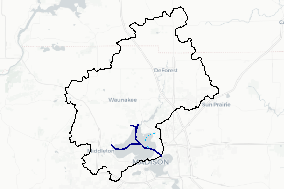

```r
prep_layer <- function(x) st_geometry(st_transform(x, 3857))

prettymapr::prettymap({
  rosm::osm.plot(sp_bbox, type = "cartolight", quiet = TRUE,
                 progress = "none", cachedir = work_dir)

  plot(prep_layer(basin),
       lwd = 2, add = TRUE)

  plot(prep_layer(flowline),
       lwd = 1.5, col = "deepskyblue", add = TRUE)

  plot(prep_layer(dplyr::filter(flowline, streamorde > 2)),
       lwd = 3, col = "darkblue", add = TRUE)

  us_nwis_layer <- prep_layer(upstream_nwis)

  plot(us_nwis_layer,
       pch = 17, cex = 1.5, col = "yellow", add = TRUE)

  label_pos <- st_coordinates(us_nwis_layer)

  text(label_pos[,1],label_pos[,2],
       upstream_nwis$identifier,
       adj = c(-0.2, 0.5), cex = 0.7)

}, drawarrow = TRUE)
```

## Plotting with ggplot2

Below is a very similar example using [`ggmap`](https://github.com/dkahle/ggmap) and [`ggplot2` `geom_sf`](https://ggplot2.tidyverse.org/reference/ggsf.html). Note that ggmap takes case of projections for us, which should either make you happy because it *just works* or very nervous because it *just works*.

[figure not shown]

```r
library(ggmap)
library(ggplot2)

upstream_nwis <- dplyr::bind_cols(upstream_nwis$UT_nwissite,
                           dplyr::rename(dplyr::as_tibble(sf::st_coordinates(upstream_nwis$UT_nwissite)),
                                         lat = Y, lon = X))

basemap_toner <- get_map(source = "stamen", maptype = "toner",
                         location = ggmap_bbox, zoom = 11, messaging = FALSE)
basemap_terrain <- get_map(source = "stamen", maptype = "terrain-lines",
                           location = ggmap_bbox, zoom = 11, messaging = FALSE)
toner_map <- ggmap(basemap_toner)
terrain_map <- ggmap(basemap_terrain)

toner_map
```

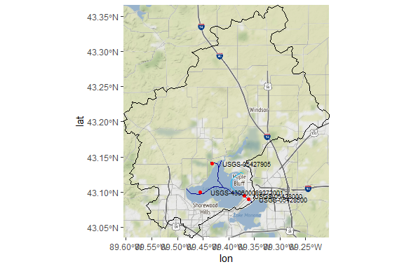

```r
terrain_map + geom_sf(data = basin,
                        inherit.aes = FALSE,
                        color = "black", fill = NA) +
  geom_sf(data = flowline,
          inherit.aes = FALSE,
          color = "deepskyblue") +
  geom_sf(data = dplyr::filter(flowline, streamorde > 2),
          inherit.aes = FALSE,
          color = "darkblue") +
  geom_sf(data = upstream_nwis, inherit.aes = FALSE, color = "red") +
  geom_text(data = upstream_nwis, aes(label = identifier, x = lon, y = lat),
            hjust = 0, size=2.5, nudge_x = 0.02, col = "black")
```

Hopefully these examples give a good head start to plotting NHDPlus data. Please submit questions via github issues for more!! Pull requests on this vignette are more than welcome if you have additions or suggestions.